# V-005 — regime × population analysis and sensitivity

**Internal scientific artifact.** The frozen endpoint hypothesis is supported, but the early adjacent-year stability diagnostic fails. This notebook does not authorize a storyboard, render, upload, scheduling, sharing or publication.

Question: from 1973 to 2025, how does the composition of political regimes differ when each eligible V-Dem political unit counts once versus when each person counts once?

```python
from pathlib import Path
import json
import pandas as pd
import matplotlib.pyplot as plt

VIDEO = Path.cwd()
ANALYTICS = VIDEO / "analytics"
MANIFESTS = VIDEO / "manifests"
plt.rcParams.update({"figure.dpi": 125, "font.size": 10, "axes.spines.top": False, "axes.spines.right": False})
```

## Inputs and independent validation

```python
gaps = pd.read_csv(ANALYTICS / "v005-annual-democracy-gap.csv")
composition = pd.read_csv(ANALYTICS / "v005-annual-regime-composition.csv")
sensitivity = pd.read_csv(ANALYTICS / "v005-sensitivity-summary.csv")
influence = pd.read_csv(ANALYTICS / "v005-unit-influence-endpoints.csv")
transitions = pd.read_csv(ANALYTICS / "v005-sign-change-transitions.csv")
decisions = json.loads((ANALYTICS / "v005-endpoint-decisions.json").read_text())
validation = json.loads((MANIFESTS / "v005-validation.json").read_text())

pd.DataFrame({
    "artifact": ["annual gaps", "composition rows", "leave-one rows", "independent validation"],
    "value": [len(gaps), len(composition), len(influence), f'{validation["passedCount"]}/{validation["checkCount"]} PASS'],
})
```

|  | artifact | value |
| --- | --- | --- |
| 0 | annual gaps | 212 |
| 1 | composition rows | 477 |
| 2 | leave-one rows | 1888 |
| 3 | independent validation | 23/23 PASS |

The analysis reads the frozen 9,056-row V-Dem v16 panel and the frozen V-004 method contract. Population sums and all decisions use decimal arithmetic without decision rounding. Missing population is not converted to zero or imputed; conservative WDI-world-reference bounds are reported.

## Endpoint result

```python
endpoints = gaps[gaps["year"].isin([1973, 2024, 2025])].copy()
endpoints[[
    "year", "classification_scenario", "country_democracy_share",
    "observed_democracy_share", "gap_observed_pp", "gap_lower_pp", "gap_upper_pp",
    "common_matched_gap_pp",
]].round(3)
```

|  | year | classification_scenario | country_democracy_share | observed_democracy_share | gap_observed_pp | gap_lower_pp | gap_upper_pp | common_matched_gap_pp |
| --- | --- | --- | --- | --- | --- | --- | --- | --- |
| 0 | 1973 | Q0_three_state | 0.196 | 0.353 | 15.638 | 11.170 | 23.842 | 12.002 |
| 1 | 1973 | Q1_midpoint_binary | 0.222 | 0.365 | 14.315 | 9.694 | 22.366 | 11.661 |
| 2 | 1973 | Q2_boundary_autocracy | 0.196 | 0.353 | 15.638 | 11.170 | 23.842 | 12.002 |
| 3 | 1973 | Q3_boundary_democracy | 0.241 | 0.372 | 13.186 | 8.468 | 21.139 | 10.105 |
| 204 | 2024 | Q0_three_state | 0.425 | 0.220 | -20.494 | -20.753 | -19.575 | -21.311 |
| 205 | 2024 | Q1_midpoint_binary | 0.480 | 0.239 | -24.128 | -24.409 | -23.232 | -25.206 |
| 206 | 2024 | Q2_boundary_autocracy | 0.425 | 0.220 | -20.494 | -20.753 | -19.575 | -21.311 |
| 207 | 2024 | Q3_boundary_democracy | 0.525 | 0.323 | -20.198 | -20.578 | -19.400 | -21.485 |
| 208 | 2025 | Q0_three_state | 0.413 | 0.219 | -19.404 | -19.745 | -18.193 | -20.505 |
| 209 | 2025 | Q1_midpoint_binary | 0.486 | 0.266 | -21.991 | -22.404 | -20.852 | -23.387 |
| 210 | 2025 | Q2_boundary_autocracy | 0.413 | 0.219 | -19.404 | -19.745 | -18.193 | -20.505 |
| 211 | 2025 | Q3_boundary_democracy | 0.531 | 0.324 | -20.665 | -21.168 | -19.616 | -21.662 |

```python
pd.DataFrame([
    {"decision": "H1 endpoint reversal", "verdict": decisions["h1"]["verdict"]},
    {"decision": "H2 strict robustness", "verdict": decisions["h2"]["verdict"]},
    {"decision": "2024 scientific endpoint gate", "verdict": decisions["publicEndpointGate2024"]["verdict"]},
    {"decision": "early adjacent stability", "verdict": "pass" if decisions["adjacentYearStability"]["early1973To1975"]["passed"] else "fail"},
    {"decision": "late adjacent stability", "verdict": "pass" if decisions["adjacentYearStability"]["late2023To2025"]["passed"] else "fail"},
])
```

|  | decision | verdict |
| --- | --- | --- |
| 0 | H1 endpoint reversal | supported |
| 1 | H2 strict robustness | supported |
| 2 | 2024 scientific endpoint gate | passed |
| 3 | early adjacent stability | fail |
| 4 | late adjacent stability | pass |

## Full trajectory and classification sensitivity

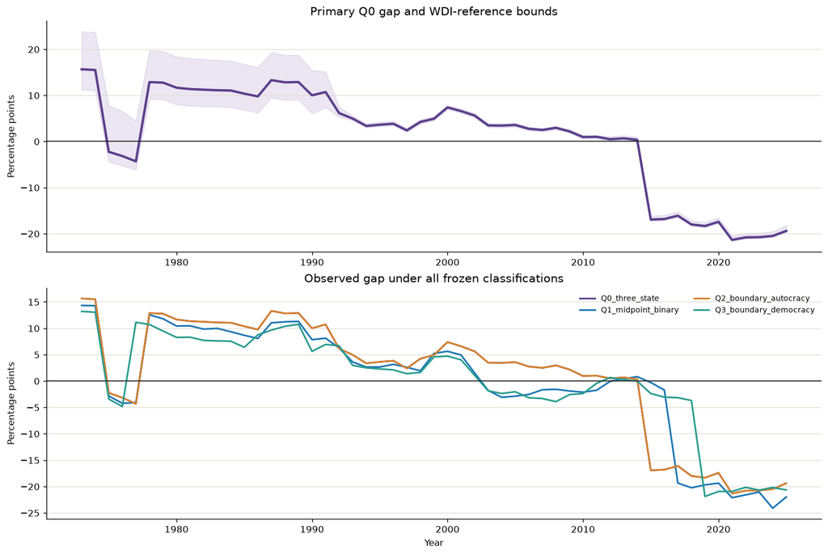

```python
colors = {
    "Q0_three_state": "#5B3F8C", "Q1_midpoint_binary": "#1F77B4",
    "Q2_boundary_autocracy": "#D9822B", "Q3_boundary_democracy": "#2A9D8F",
}
primary = gaps[gaps["classification_scenario"].eq("Q0_three_state")]
fig, axes = plt.subplots(2, 1, figsize=(12, 8), constrained_layout=True)
axes[0].fill_between(primary["year"], primary["gap_lower_pp"], primary["gap_upper_pp"], color="#B9A7D0", alpha=.28)
axes[0].plot(primary["year"], primary["gap_observed_pp"], color="#5B3F8C", linewidth=2.5)
axes[0].axhline(0, color="#222", linewidth=1)
axes[0].set(title="Primary Q0 gap and WDI-reference bounds", ylabel="Percentage points")
for scenario, color in colors.items():
    frame = gaps[gaps["classification_scenario"].eq(scenario)]
    axes[1].plot(frame["year"], frame["gap_observed_pp"], label=scenario, color=color, linewidth=1.8)
axes[1].axhline(0, color="#222", linewidth=1)
axes[1].set(title="Observed gap under all frozen classifications", xlabel="Year", ylabel="Percentage points")
axes[1].legend(frameon=False, ncol=2, fontsize=8)
for ax in axes:
    ax.grid(axis="y", color="#E1DED5")
plt.show()
```

The observed Q0 gap is positive in 1973 and negative in 2025, and the worst-case bounds preserve the required signs in Q0–Q3 for 1973, 2024 and 2025. The trajectory is not linear: sign changes occur in 1974→1975, 1977→1978 and 2014→2015.

## What changes at the sign crossings?

```python
transitions[[
    "from_year", "to_year", "country_name", "from_v2x_regime_amb",
    "to_v2x_regime_amb", "from_state", "to_state", "to_population",
]]
```

|  | from_year | to_year | country_name | from_v2x_regime_amb | to_v2x_regime_amb | from_state | to_state | to_population |
| --- | --- | --- | --- | --- | --- | --- | --- | --- |
| 0 | 1974 | 1975 | Suriname | 5 | 3 | boundary | autocracy | NaN |
| 1 | 1974 | 1975 | Colombia | 3 | 4 | autocracy | boundary | 2.334464e+07 |
| 2 | 1974 | 1975 | India | 6 | 3 | democracy | autocracy | 6.113095e+08 |
| 3 | 1974 | 1975 | Papua New Guinea | 5 | 6 | boundary | democracy | NaN |
| 4 | 1974 | 1975 | Greece | 3 | 7 | autocracy | democracy | 9.046541e+06 |
| 5 | 1977 | 1978 | Colombia | 4 | 3 | boundary | autocracy | 2.495034e+07 |
| 6 | 1977 | 1978 | India | 4 | 6 | boundary | democracy | 6.557282e+08 |
| 7 | 1977 | 1978 | Papua New Guinea | 6 | 5 | democracy | boundary | 3.003714e+06 |
| 8 | 1977 | 1978 | Spain | 3 | 7 | autocracy | democracy | 3.686490e+07 |
| 9 | 1977 | 1978 | Solomon Islands | 3 | 4 | autocracy | boundary | NaN |
| 10 | 2014 | 2015 | Pakistan | 4 | 3 | boundary | autocracy | 2.172909e+08 |
| 11 | 2014 | 2015 | India | 6 | 5 | democracy | boundary | 1.328024e+09 |
| 12 | 2014 | 2015 | Burkina Faso | 6 | 3 | democracy | autocracy | 1.877749e+07 |
| 13 | 2014 | 2015 | Guinea-Bissau | 3 | 5 | autocracy | boundary | 1.786457e+06 |
| 14 | 2014 | 2015 | Sri Lanka | 3 | 5 | autocracy | boundary | 2.097000e+07 |
| 15 | 2014 | 2015 | Comoros | 4 | 3 | boundary | autocracy | 7.266820e+05 |

This table is a classification-transition diagnostic, not a causal decomposition. India is the largest population-weighted transition at each observed sign crossing, but other unit changes and annual denominator changes also occur. Explaining any transition historically requires a separate sourced study.

## Sensitivity suite

```python
sensitivity
```

|  | sensitivity_id | diagnostic | status | decision_effect | detail |
| --- | --- | --- | --- | --- | --- |
| 0 | S1 | Q0 boundary separate | pass | H1 supported | Primary three-state analysis. |
| 1 | S2 | Q1 midpoint binary | pass | H2 component | Codes 0-4 autocracy; 5-9 democracy. |
| 2 | S3 | Q2 boundary autocratic | pass | H2 component | Codes 0-5 autocracy; 6-9 democracy. |
| 3 | S4 | Q3 boundary democratic | pass | H2 component | Codes 0-3 autocracy; 4-9 democracy. |
| 4 | S5 | Unobserved population bounds | pass | H2 supported | All Q0-Q3 worst-case endpoint bounds retain re... |
| 5 | S6 | Co-housed 2024 endpoint | pass | 2024 scientific endpoint component | Q0 observed gap -20.49400688642683171766653268... |
| 6 | S7 | Common matched universe | measured_no_threshold | Does not alter H1 rule | Q0 matched gaps: 1973 12.002450424218275023193... |
| 7 | S8 | Adjacent years | warning | Weakens endpoint narrative without rejecting H1 | 1973-1975 fails stability; 2023-2025 passes. T... |
| 8 | S9 | Leave one population unit out | pass_no_sign_flip | No endpoint decision flip | Largest Q0 changes: 1973 India 13.338819573646... |
| 9 | S10 | External compatible classification | not_testable | No external evidence added | No separately contracted compatible external c... |
| 10 | S11 | Source revision | not_testable | No revision comparison | Only V-Dem v16 and one frozen population snaps... |

```python
top_influence = (
    influence.assign(absolute_change_pp_numeric=lambda x: x["absolute_change_pp"].astype(float))
    .query('classification_scenario == "Q0_three_state"')
    .sort_values(["year", "absolute_change_pp_numeric"], ascending=[True, False])
    .groupby("year", as_index=False).head(5)
)
top_influence[["year", "country_name", "state", "removed_population", "absolute_change_pp", "new_gap_observed_pp", "sign_flip"]]
```

|  | year | country_name | state | removed_population | absolute_change_pp | new_gap_observed_pp | sign_flip |
| --- | --- | --- | --- | --- | --- | --- | --- |
| 26 | 1973 | India | democracy | 5.834656e+08 | 13.338820 | 2.299192 | False |
| 84 | 1973 | China | autocracy | 8.819400e+08 | 12.274026 | 27.912037 | False |
| 12 | 1973 | United States of America | democracy | 2.119090e+08 | 4.282635 | 11.355376 | False |
| 5 | 1973 | Japan | democracy | 1.087070e+08 | 2.128378 | 13.509633 | False |
| 41 | 1973 | Indonesia | autocracy | 1.252885e+08 | 1.342649 | 16.980660 | False |
| 547 | 2024 | India | autocracy | 1.450936e+09 | 4.832889 | -15.661118 | False |
| 616 | 2024 | China | autocracy | 1.408975e+09 | 4.663447 | -15.830560 | False |
| 531 | 2024 | United States of America | democracy | 3.401110e+08 | 3.444669 | -23.938676 | False |
| 530 | 2024 | Brazil | democracy | 2.119986e+08 | 2.112020 | -22.606027 | False |
| 522 | 2024 | Japan | democracy | 1.239754e+08 | 1.221370 | -21.715377 | False |
| 1232 | 2025 | India | autocracy | 1.463866e+09 | 4.847775 | -14.556530 | False |
| 1301 | 2025 | China | autocracy | 1.406585e+09 | 4.618149 | -14.786156 | False |
| 1215 | 2025 | United States of America | democracy | 3.417849e+08 | 3.444407 | -22.848712 | False |
| 1214 | 2025 | Brazil | democracy | 2.128124e+08 | 2.109537 | -21.513842 | False |
| 1206 | 2025 | Japan | democracy | 1.233667e+08 | 1.209159 | -20.613464 | False |

No leave-one-unit-out endpoint calculation flips the sign. India has the largest Q0 influence in 1973, 2024 and 2025, so the population weighting is substantively concentrated even though the formal endpoint decision is not determined by one unit alone.

## Conclusions and limits

- H1 is supported under the frozen Q0 endpoint rule.
- H2 is supported under all four frozen classifications and the conservative missing-population bounds.
- The co-housed 2024 scientific endpoint gate passes and independent validation reports 23/23 checks.
- The early adjacent-year diagnostic fails: the 1973 positive sign does not persist through 1975. The late endpoint is stable from 2023 through 2025.
- Therefore a future public artifact may be eligible to show a non-linear reversal, but must not present it as gradual, monotonic, causal or uniformly global.
- S10 external classification and S11 source revision remain not testable because no compatible external classification or second official snapshot was contracted.

These are ecological, descriptive comparisons between denominators. They do not show that regime type causes population change, do not describe individual political experience, and do not rank countries morally.

**Authority:** no storyboard, render, upload, scheduling, sharing or publication is authorized by this notebook.